# Simple linear regression

## Tooth growth data

- We’ll now use the `ToothGrowth` data to illustrate a model with a categorical variable:

```r
str(ToothGrowth)
```

```
## 'data.frame':    60 obs. of  3 variables:
##  $ len : num  4.2 11.5 7.3 5.8 6.4 10 11.2 11.2 5.2 7 ...
##  $ supp: Factor w/ 2 levels "OJ","VC": 2 2 2 2 2 2 2 2 2 2 ...
##  $ dose: num  0.5 0.5 0.5 0.5 0.5 0.5 0.5 0.5 0.5 0.5 ...
```

- `ToothGrowth` contains observations on 60 guinea pigs with variables:
  - `len`: the tooth length
  - `supp`: supplement type (VC = vitamin C, OJ = orange juice)
  - `dose`: dose of supplement in milligrams/days

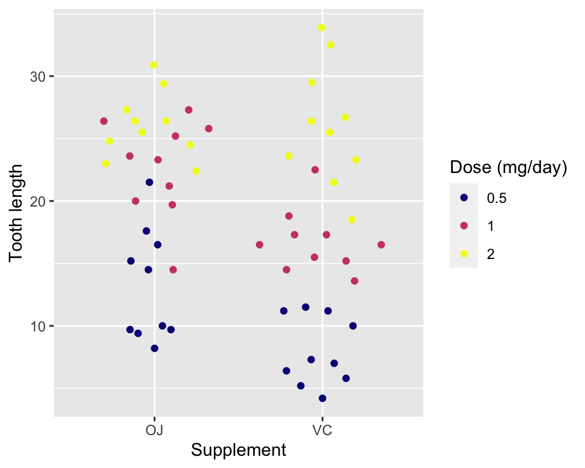

## Fitting a categorical variable in `lm`: illustration

- `supp` is a factor with two levels: “VC” and “OJ”
- What model are we fitting below?

```r
fit1s <- lm(len ~ 1 + as.numeric(supp=="VC") + as.numeric(supp=="OJ") , data = ToothGrowth)
```

$$\color{#006dae}{y_{ij}} = \beta_0\cdot \color{#006dae}{1} + \beta_1 \color{#006dae}{x_{1i}}+ \beta_2 \color{#006dae}{x_{2i}} + e_{ij}, \qquad \text{for }i = 1, 2, j = 1, 2, 3$$
where:

- $i$ corresponds to the level of the supplementary variable,
- $j$ corresponds to the dose level,
- $x_{1i} = \begin{cases}1\quad\text{if }i=1\\0\quad\text{if }i=2\end{cases},$
- $x_{2i} = \begin{cases}1\quad\text{if }i=2\\0\quad\text{if }i=1\end{cases},$ and
- in this case the system is singular so the last term is dropped (same as $\beta_2 = 0$).

## Fitting a categorical variable in `lm`: convenient approach

- Instead of creating dummy variables, like $x_{1i}$ and $x_{2i}$, for every level of a categorical variable, it is more convenient to use the categorical variable directly in the symbolic formula like below:

```r
fit2s <- lm(len ~ supp, data = ToothGrowth)
```

- Above model is the equivalent as `fit1s`:

```r
coef(fit1s)
```

```
##              (Intercept) as.numeric(supp == "VC") as.numeric(supp == "OJ")
##                 20.66333                 -3.70000                       NA
```

```r
coef(fit2s)
```

```
## (Intercept)      suppVC
##    20.66333    -3.70000
```

- By default `lm` uses the treatment constraint (`?contr.treatment`), i.e. first level of the categorical is omitted (same as constraining the corresponding coefficient to zero).

## Predicted values

$$\widehat{\texttt{len}} = 20.66 - 3.7 \cdot \texttt{supp}_{\texttt{VC}}$$

- There are only two possible response values from this model:

```r
predict(fit2s, data.frame(supp = c("OJ", "VC")))
```

```
##        1        2
## 20.66333 16.96333
```

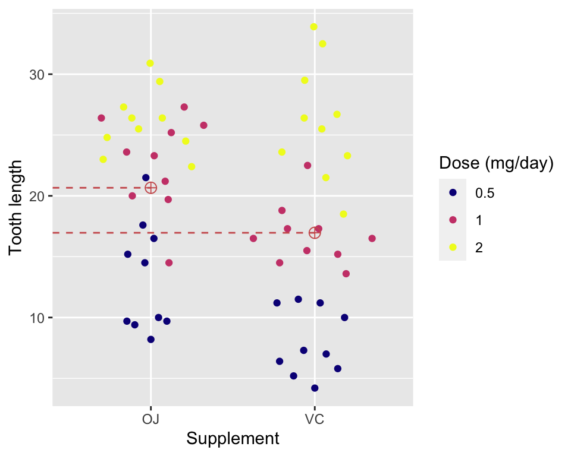

- Is this a reasonable model?

## An alternative model

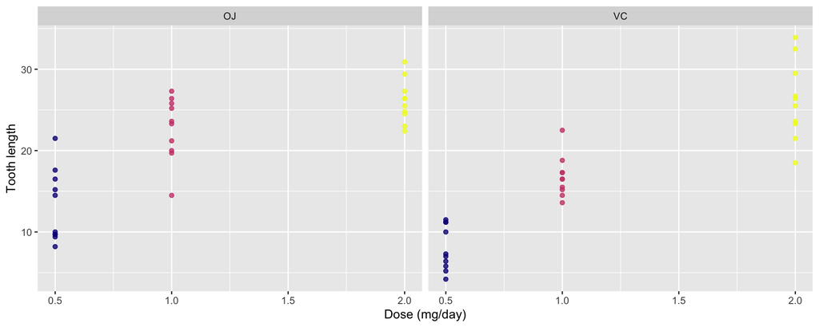

- We can see that tooth length appears to be determined by the dose level of the supplementary